# BAMexploreR: model-based distribution, abundance, and habitat associations of boreal birds **Distribution and Abundance**

This vignette will show you how to work with the BAM landbird density models to evaluate distribution and population size with the `BAMExploreR` package.

## Background

### Density estimates

The BAM landbird density models use the [QPAD analytical approach for data integration](https://besjournals.onlinelibrary.wiley.com/doi/full/10.1111/2041-210x.12106), which uses statistical offsets to account for imperfect detection and produce estimates of population density. The model products are therefore species-specific predictions of the density of breeding male birds per hectare at a 1km resolution across the boreal forest! We can use those density surfaces for a variety of conservation and land-use planning applications. The `BAMexploreR` package provides functions for two core analytical tasks. For more information on the BAM landbird density models, please see the ‘Introduction’ vignette.

## Functions available

### bam_occurrence()

**bam_occurrence()** estimates a species’ presence/absence threshold based on a Lorenz curve. This curve is fitted using the [opticut package](https://rdrr.io/cran/opticut/man/lorenz.html), which analyses the spatial inequality in predicted density across an area of interest. `opticut` distinguishes “presence” from “absence” by identifying pixels of a certain density value that have a negligible contribution to the area’s total population. Therefore, this function helps distinguish between areas of high and low predicted use, by determining a threshold value that defines the most likely occupied areas.

Arguments

- raster_list: A named list of SpatRaster objects, each representing predicted density for a species.
- quantile: Method to derive the threshold; default is “by_lorenz”.
- plot: Logical, if TRUE returns a map with binary presence (1) / absence (0) values.

Output

A tibble with the following columns:

- species: Species code identifying the species.
- type: Indicates whether a presence/absence threshold was applied when calculating the area. Values are “no_threshold” or “with_threshold”.
- area_km2: The total area (in square kilometers) where predicted abundance exceeds the threshold (if applied).

### bam_pop_size()

**bam_pop_size()** estimates the total population size by summarizing predicted densities of males across a spatial extent. This function supports cropping to a defined area (e.g., a region of interest) and group-based summaries if the extent includes a grouping variable (e.g., subregions, jurisdictions).

Arguments

- raster_list: A named list of SpatRaster objects, each representing predicted density for a species.
- crop_ext: A SpatVector defining the spatial extent for the cropping and grouping of population estimates.
- group: (Optional) Name of the column in crop_ext to use for grouping population estimates.

Output

A tibble with the following columns:

- group: Group identifier, such as a region or subunit (set to NA if no grouping was applied).
- total_pop: Estimated total number of males across the area (inferred from pixel-level densities).
- mean_density: Average predicted density (males per pixel).
- sd_density: Standard deviation of predicted densities.
- n_cells: Number of raster cells included in the calculation.
- species: Species code identifying the species.

## Example workflow

### 1. Model access

The first step in working with the BAM density models is to get the model layers for the species and area of interest. See the ‘Model Access’ vignette for further details.

We’ll use the same example as the previous vignette: Olive-sided Flycatcher within an area of interest (AOI) across two sugbregions in the boreal plains and shield. This time, instead of downloading the model products for the whole subregions, we’ll use the `crop_ext` argument to download just the AOI.

```r
library(BAMexploreR)

# Use the example aoi SpatVector provided in the package
aoi_sf <- vect(system.file("extdata", "vignette_poly_5072.shp", package = "BAMexploreR"))

#Download the model products
result <- bam_get_layer("OSFL", "v5", destfile = tempdir(), year = "2020", crop_ext=aoi_sf)
```

Let’s plot just the mean density to check our download.

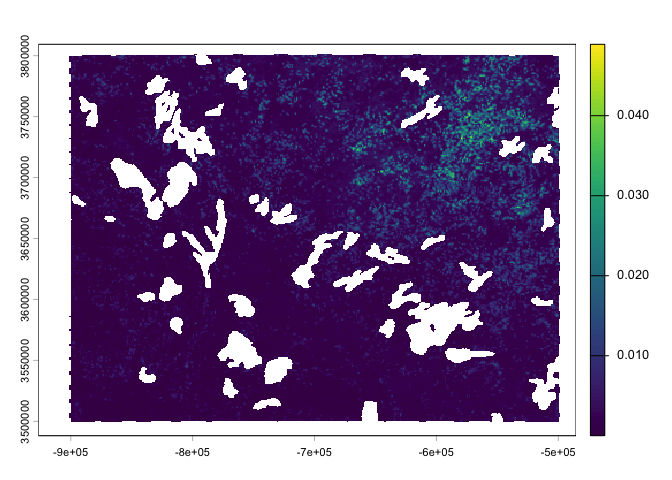

```r
library(terra)
plot(result$OSFL$mean)
```

Great! We can see this time our raster is limited to just the extent of our AOI.

### 2. Estimate area of occurrence

Once we have our models for our AOI, we can use the `bam_occurrence` function to threshold the continuous density surface into a binary occurrence surface, for example to identify areas of ‘high-quality’ habitat.

There are two options for thresholding the continuous values into presence and absence.

- **by_lorenz**: Using a Lorenz curve, which summarizes the spatial inequality in predicted occurrence probabilities. See the [`opticut` R package](https://github.com/psolymos/opticut) for details.
- **numeric**: Using a custom threshold between 0 and 1. This value indicates a cumulative proportion of pixels, above which all raster pixel values are assigned as “presence”.

Let’s try the default option, `by_lorenz` first on downloaded models for Olive-sided Flycatcher.

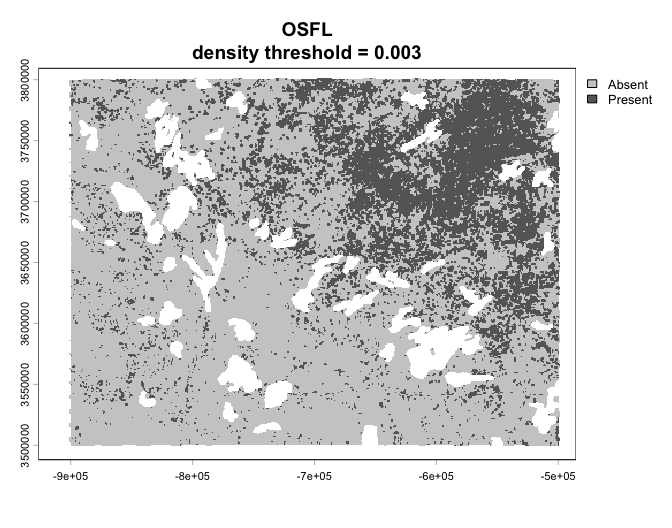

```r
# Threshold the model with the lorenz curve threshold
occ_lorenz_result <- bam_occurrence(result, plot = TRUE)
```

And then let’s compare to a custom threshold; let’s try 50%.

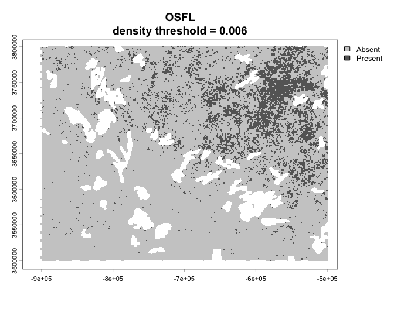

```r
# Threshold the model with 50% threshold
occ_quantile_result <- bam_occurrence(result, quantile = 0.5, plot = TRUE)
```

We can see that the area of occurrence is smaller when we use a more conservative threshold! Let’s examine the area of occurrence within our AOI for the two approaches to compare.

```r
library(knitr)

# Area of occurrence for lorenz approach
kable(occ_lorenz_result$occurrence_summary, caption="Area of occurence with Lorenz threshold")
```

Area of occurence with Lorenz threshold

| species | type | area_km2 |
| --- | --- | --- |
| OSFL | no_threshold | 108000 |
| OSFL | with_threshold | 30000 |

```r
# Area of occurence for quantile approach
kable(occ_quantile_result$occurrence_summary, caption="Area of occurence with 50% threshold")
```

Area of occurence with 50% threshold

| species | type | area_km2 |
| --- | --- | --- |
| OSFL | no_threshold | 108000 |
| OSFL | with_threshold | 13900 |

### 3. Estimate population size

Alternatively, we can use the the `bam_pop_size` function on the continuous density predictions to calculate population size! This function simply sums the value of the pixels across the AOI and corrects for raster cell size.

Let’s use our same Olive-sided Flycatcher example as before.

```r
# Calculate population size based on BAM landbird density raster
pop_aoi_result <- bam_pop_size(result)
Aligning projections
Calculating population size - be patient!

# Show results
kable(pop_aoi_result, caption = "Estimated population size (male birds)")
```

Estimated population size (male birds)

| species | group | total_pop | mean_density | sd_density | n_cells |
| --- | --- | --- | --- | --- | --- |
| OSFL | NA | 36200 | 0.003 | 0.004 | 121033 |

The `bam_pop_size` function can also accommodate an AOI SpatVector for AOI with a column that can be used to group the population size summary.

Let’s imagine a regional planning project where we need to know which BCR (in our AOI) has a larger Olive-sided Flycatcher population. We might start by creating a new SpatVector with separate polygons for the two BCRs in our AOI.

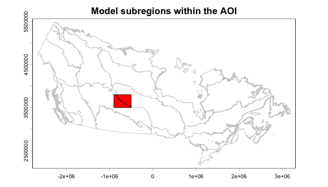

```r
# Get the BCR names that intersect our AOI
bcraoi_v5 <- bam_get_bcr(version="v5", ext=aoi_sf)

# Get the BCRs of interest from model subregion layer provided in the package
bcr_v5 <- vect(system.file("extdata", "BAM_BCRNMv5_5072.shp", package = "BAMexploreR"))
aoi_bcr <- bcr_v5[bcr_v5$subunit_ui %in% bcraoi_v5, ]

# Crop the BCR SpatVector to our AOI
aoi_sf_bcr <- terra::crop(aoi_bcr, aoi_sf)

# Plot to check the result
plot(bcr_v5, border = "grey80", main = "Model subregions within the AOI")
plot(aoi_sf_bcr, col = "red", border = "black", add = TRUE)
```

Looks good! Now we can use that new SpatVector with the BCRs to group our population estimates by BCR.

```r
# Check what the BCR column name is called
head(aoi_sf_bcr)
  subUnit country subunit_ui          X       Y     type
1      61     can      can61 -947405.68 3594125 mainland
2      80     can      can80  -11870.64 3451937 mainland

# Calculate population size based on BAM landbird density raster
pop_bcr_result <- bam_pop_size(result, crop_ext=aoi_sf_bcr, group="subunit_ui")
Aligning projections
Calculating population size - be patient!

# Show results
kable(pop_bcr_result, caption = "Estimated population size")
```

Estimated population size

[output not shown]